# Ford GoBike System Data Exploration

## Preliminary Wrangling

In this notebook we will explore the data and we will create new features (Feature Engineering) and visualize them and finally summarize our findings from these visuals. The Data set I will be working on is **Ford GoBike System Data**.

### What is the structure of your dataset?

There are 18,3412 bike records in the dataset with 16 features ('duration_sec', 'start_time', 'end_time', 'start_station_id', 'start_station_name', 'start_station_latitude','start_station_longitude', 'end_station_id', 'end_station_name', 'end_station_latitude', 'end_station_longitude', 'bike_id', 'user_type','member_birth_year', 'member_gender', 'bike_share_for_all_trip'). Most variables are numeric in nature, but the variables member_gender and bike_share_for_all_trip are both categorical (nominal variables).

### What is/are the main feature(s) of interest in your dataset?

I'm most interested in figuring out what features are best for predicting the average velocity (which is a feature that I am going to create using current features)(Feature Engineering). I will need to use the following features to calculate the average velocity for each ride [duration_sec, start_station_latitude , end_station_latitude , start_station_longitude , end_station_longitude ].

### What features in the dataset do you think will help support your investigation into your feature(s) of interest?

I expect that member_birth_year (age) will have the strongest effect on the velocity: the younger the diamond, the faster the ride. I also think that the user_type and gender will affect the average velocity. I expect that men will be faster than women and subscribers will be faster than normal customers.

In the next cells I will create the new features and I will do some data cleaning in the dataframe before we visualize the data.

## Univariate Exploration

Here we will interpret each variable alone starting with the velocity variable.

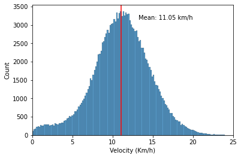

We can see that the average speed is normally distrubted with mean 11.05 km/h. I expected that the distrubution would be normal since there will be fast bikers and others slow but the majority would be in between those two extrems.We don't need to perform any transfomations on this variable.  
Now let's investigate the rest of the variables.

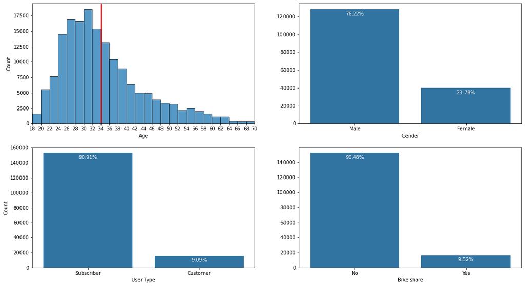

## Bivariate Exploration

Here we will interpret two variables at a time to see interactions between variables. We will begin first by the age and velocity.

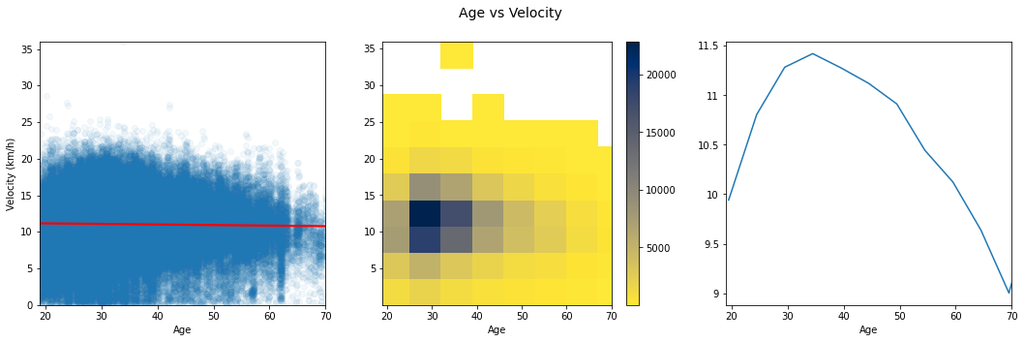

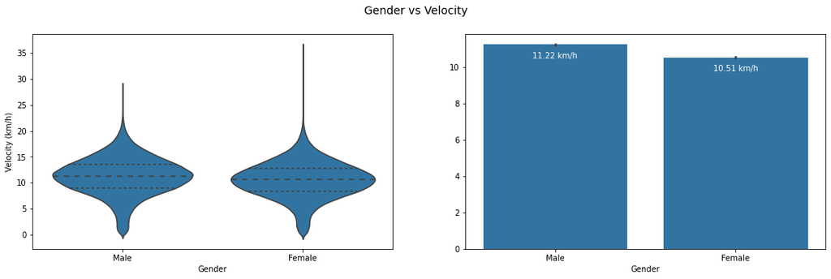

#### Comments :

1) There is no big difference between both distrubutions.  
2) The women have much more outliers than males. Which means that the fastest ones are women.  
3) The Males are faster on average than women but not significantly faster.

Now we will look at the last two variables which are the user_type and bike_share.

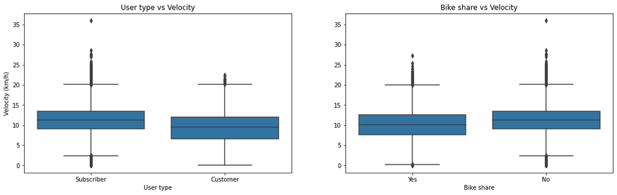

#### Comments :

1) Subscibers tends to be much faster than customers. The average of subscribers is bigger than the customers.  
2) The fastest bikers are subscibers.  
3) From subscribers (All of the bikers who share their bikes are subscribers), Those who doesn't share their bikes are faster than those who does.

## Multivariate Exploration

I mostly intersted in how the gender and age play roles in predecting velocity. And also how the gender and user type play roles in the prediction. Let's start with the gender and age.

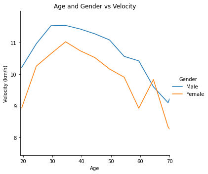

#### Comments :

1) We can see that males are faster than women nearly for all ages. Since the blue line is above the yellow line which indicates that their velocity is higher.  
2) I didn't use either heat map or scatter plot because there are many data points and they weren't clear enough.

Finally let's see the relation between gender and user_type vs velocity.

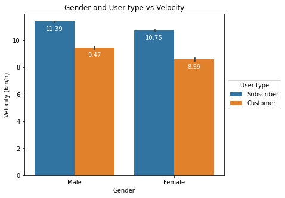

#### Comments :

1) We can see that subsribers have mean velocity higher than normal customers.  
2) We can see also that males have higher mean velocity than females. Since males subscibers mean velocity is biiger than females and also this goes for the males customers.

## Were there any interesting or surprising interactions between features?

All the results were expected. But my expectaions were higher such that the relation between age and average velocity would be stronger and that men would be faster more significantly than it appeared.